# Numerical Methods

Sachin

29/01/2023

# 1)x^3-2x-5=0

```r
f=function(x){return(x^3-2*x-5)}
a=1
b=3
x=(a+b)/2
df=data.frame(a,b,x,f(a),f(b),f(a)*f(x))
df
```

```
##   a b x f.a. f.b. f.a....f.x.
## 1 1 3 2   -6   16           6
```

```r
for(i in seq(2,15))
{
  if(f(a)*f(x)<=0){b=x}else{a=x}
  x=(a+b)/2
  df=rbind(df,data.frame(a,b,f(a),f(b),x,f(a)*f(x)))
}
df
```

```
##           a        b        x          f.a.         f.b.   f.a....f.x.
## 1  1.000000 3.000000 2.000000 -6.0000000000 1.600000e+01  6.000000e+00
## 2  2.000000 3.000000 2.500000 -1.0000000000 1.600000e+01 -5.625000e+00
## 3  2.000000 2.500000 2.250000 -1.0000000000 5.625000e+00 -1.890625e+00
## 4  2.000000 2.250000 2.125000 -1.0000000000 1.890625e+00 -3.457031e-01
## 5  2.000000 2.125000 2.062500 -1.0000000000 3.457031e-01  3.513184e-01
## 6  2.062500 2.125000 2.093750 -0.3513183594 3.457031e-01  3.141366e-03
## 7  2.093750 2.125000 2.109375 -0.0089416504 3.457031e-01 -1.491787e-03
## 8  2.093750 2.109375 2.101562 -0.0089416504 1.668358e-01 -7.024763e-04
## 9  2.093750 2.101562 2.097656 -0.0089416504 7.856226e-02 -3.104030e-04
## 10 2.093750 2.097656 2.095703 -0.0089416504 3.471428e-02 -1.150105e-04
## 11 2.093750 2.095703 2.094727 -0.0089416504 1.286233e-02 -1.747510e-05
## 12 2.093750 2.094727 2.094238 -0.0089416504 1.954348e-03  3.125240e-05
## 13 2.094238 2.094727 2.094482 -0.0034951492 1.954348e-03  2.693974e-06
## 14 2.094482 2.094727 2.094604 -0.0007707752 1.954348e-03 -4.560620e-07
## 15 2.094482 2.094604 2.094543 -0.0007707752 5.916927e-04  6.903423e-08
```

```r
c(x,f(x))
```

```
## [1]  2.094543e+00 -8.956468e-05
```

```r
f=function(x){return(x*tan(x)+1)}
a=2
b=3
x=(a+b)/2
df=data.frame(a,b,x,f(a),f(b),f(a)*f(x))
df
```

```
##   a b   x     f.a.      f.b. f.a....f.x.
## 1 2 3 2.5 -3.37008 0.5723604    2.923732
```

```r
for(i in seq(2,3))
{
  if(f(a)*f(x)<=0){b=x}else{a=x}
  x=(a+b)/2
  df=rbind(df,data.frame(a,b,f(a),f(b),x,f(a)*f(x)))
}
df
```

```
##      a b     x       f.a.      f.b. f.a....f.x.
## 1 2.00 3 2.500 -3.3700797 0.5723604  2.92373202
## 2 2.50 3 2.750 -0.8675557 0.5723604  0.11757481
## 3 2.75 3 2.875 -0.1355242 0.5723604 -0.02911831
```

```r
#or
f=function(x){return(x*tan(x)+1)}
a=2
b=3
x=(a+b)/2
err=1
df=data.frame(a,b,f(a),f(b),x,f(x))
while(err>=0.00001){
  x0=x
  if(f(a)*f(x)<=0){b=x}else{a=x}
  x=(a+b)/2
  df=rbind(df,data.frame(a,b,f(a),f(b),x,f(x)))
  err=abs(x-x0)
}
df
```

```
##           a        b          f.a.         f.b.        x          f.x.
## 1  2.000000 3.000000 -3.370080e+00 0.5723603708 2.500000 -8.675557e-01
## 2  2.500000 3.000000 -8.675557e-01 0.5723603708 2.750000 -1.355242e-01
## 3  2.750000 3.000000 -1.355242e-01 0.5723603708 2.875000  2.148569e-01
## 4  2.750000 2.875000 -1.355242e-01 0.2148569195 2.812500  3.949924e-02
## 5  2.750000 2.812500 -1.355242e-01 0.0394992354 2.781250 -4.795860e-02
## 6  2.781250 2.812500 -4.795860e-02 0.0394992354 2.796875 -4.228493e-03
## 7  2.796875 2.812500 -4.228493e-03 0.0394992354 2.804688  1.763416e-02
## 8  2.796875 2.804688 -4.228493e-03 0.0176341642 2.800781  6.702720e-03
## 9  2.796875 2.800781 -4.228493e-03 0.0067027205 2.798828  1.237108e-03
## 10 2.796875 2.798828 -4.228493e-03 0.0012371084 2.797852 -1.495691e-03
## 11 2.797852 2.798828 -1.495691e-03 0.0012371084 2.798340 -1.292911e-04
## 12 2.798340 2.798828 -1.292911e-04 0.0012371084 2.798584  5.539086e-04
## 13 2.798340 2.798584 -1.292911e-04 0.0005539086 2.798462  2.123087e-04
## 14 2.798340 2.798462 -1.292911e-04 0.0002123087 2.798401  4.150880e-05
## 15 2.798340 2.798401 -1.292911e-04 0.0000415088 2.798370 -4.389116e-05
## 16 2.798370 2.798401 -4.389116e-05 0.0000415088 2.798386 -1.191180e-06
## 17 2.798386 2.798401 -1.191180e-06 0.0000415088 2.798393  2.015881e-05
```

```r
cat("x=",x,"f(x)=",f(x))
```

```
## x= 2.798393 f(x)= 2.015881e-05
```

# x^3-5x+1=0

```r
f=function(x){return(x^3-5*x+1)}
x0=0
x1=1
x2=x1-((x1-x0)/(f(x1)-f(x0)))*f(x1)
err=1
df=data.frame(x2,f(x2))
while(err>=0.00001){
  err=abs(x2-x1)
  x0=x1
  x1=x2
  x2=x1-(x1-x0)*f(x1)/(f(x1)-f(x0))
  df=rbind(df,data.frame(x2,f(x2)))
}
df
```

```
##          x2         f.x2.
## 1 0.2500000 -2.343750e-01
## 2 0.1864407  7.427731e-02
## 3 0.2017363 -4.711162e-04
## 4 0.2016399 -8.642293e-07
## 5 0.2016397  1.035272e-11
## 6 0.2016397 -2.220446e-16
```

```r
cat("x=",x2,"f(x)=",f(x2))
```

```
## x= 0.2016397 f(x)= -2.220446e-16
```

# Newton Raphson Method

```r
f=function(x){return(x^2-4*x-7)}
f1=function(x){return(2*x-4)}
x=rep(0,100)
x[1]=5
err1=1
i=1
while(err1>=0.0001){x[i+1]=x[i]-(f(x[i])/f1(x[i]));
err1=abs(x[i+1]-x[i]);
i=i+1;
}
x[1:i]
```

```
## [1] 5.000000 5.333333 5.316667 5.316625
```

```r
data.frame("x"=x[1:i],"fx"=f(x[1:i]))
```

```
##          x            fx
## 1 5.000000 -2.000000e+00
## 2 5.333333  1.111111e-01
## 3 5.316667  2.777778e-04
## 4 5.316625  1.753602e-09
```

## Linear System of Algebraic Equations

# 1)Gauss Elimination Method

```r
A=matrix(c(0,2,5,7,1,-2,2,3,8), nrow=3,byrow=T)
b=c(7,6,13)
A=cbind(A,b)
if(min(diag(A))==0){A=A[c(2,1,3),]}
A
```

```
##              b
## [1,] 7 1 -2  6
## [2,] 0 2  5  7
## [3,] 2 3  8 13
```

```r
if(A[2,1]!=0){A[2,]=A[2,]-A[2,1]*A[1,]/A[1,1]}
if(A[3,1]!=0){A[3,]=A[3,]-A[3,1]*A[1,]/A[1,1]}
A
```

```
##                                  b
## [1,] 7 1.000000 -2.000000  6.00000
## [2,] 0 2.000000  5.000000  7.00000
## [3,] 0 2.714286  8.571429 11.28571
```

```r
if(A[3,2]!=0){A[3,]=A[3,]-A[3,2]*A[2,]/A[2,2]}
A
```

```
##                           b
## [1,] 7 1 -2.000000 6.000000
## [2,] 0 2  5.000000 7.000000
## [3,] 0 0  1.785714 1.785714
```

```r
x=c(0,0,0)
x[3]=A[3,4]/A[3,3]
x[2]=(A[2,4]-A[2,3]*x[3])/A[2,2]
x[1]=(A[1,4]-A[1,2]*x[2]-A[1,3]*x[3])/A[1,1]
x
```

```
## [1] 1 1 1
```

# 2)Gauss Jordan Method

```r
A=matrix(c(1,1,1,4,3,-1,3,5,3), nrow=3,byrow=T)
b=diag(3)
A=cbind(A,b)
print(A)
```

```
##      [,1] [,2] [,3] [,4] [,5] [,6]
## [1,]    1    1    1    1    0    0
## [2,]    4    3   -1    0    1    0
## [3,]    3    5    3    0    0    1
```

```r
if(A[1,1]!=0){
  A[2,]=A[2,]-A[2,1]/A[1,1]*A[1,]
  A[3,]=A[3,]-A[3,1]/A[1,1]*A[1,]
  print(A)}
```

```
##      [,1] [,2] [,3] [,4] [,5] [,6]
## [1,]    1    1    1    1    0    0
## [2,]    0   -1   -5   -4    1    0
## [3,]    0    2    0   -3    0    1
```

```r
if(A[2,2]!=0){
  A[3,]=A[3,]-A[3,2]/A[2,2]*A[2,]
  A[1,]=A[1,]-A[1,2]/A[2,2]*A[2,]
  print(A)}
```

```
##      [,1] [,2] [,3] [,4] [,5] [,6]
## [1,]    1    0   -4   -3    1    0
## [2,]    0   -1   -5   -4    1    0
## [3,]    0    0  -10  -11    2    1
```

```r
if(A[3,3]!=0){
  A[2,]=A[2,]-A[2,3]/A[3,3]*A[3,]
  A[1,]=A[1,]-A[1,3]/A[3,3]*A[3,]
  print(A)}
```

```
##      [,1] [,2] [,3]  [,4] [,5] [,6]
## [1,]    1    0    0   1.4  0.2 -0.4
## [2,]    0   -1    0   1.5  0.0 -0.5
## [3,]    0    0  -10 -11.0  2.0  1.0
```

```r
A=A/diag(A)
print(A)
```

```
##      [,1] [,2] [,3] [,4] [,5] [,6]
## [1,]    1    0    0  1.4  0.2 -0.4
## [2,]    0    1    0 -1.5  0.0  0.5
## [3,]    0    0    1  1.1 -0.2 -0.1
```

## Iterative Methods

### Gauss Jacobi Iterative Method:

```r
A=matrix(c(4,1,1,1,5,2,1,2,3),nrow=3,ncol=3,byrow=T)
b=matrix(c(2,-6,-4),nrow=3)
x0=c(0,0,0)
x1=c(0,0,0)
err=1
m=x0
while(err>0.00001)
{
  x1[1]=(b[1]-A[1,2]*x0[2]-A[1,3]*x0[3])/A[1,1]
  x1[2]=(b[2]-A[2,1]*x0[1]-A[2,3]*x0[3])/A[2,2]
  x1[3]=(b[3]-A[3,1]*x0[1]-A[3,2]*x0[2])/A[3,3]
  err=max(abs(x0-x1))
  x0=x1
  m=rbind(m,x0)
}
m=data.frame(m)
row.names(m)=seq(0,nrow(m)-1,1)
m
```

```
##           X1         X2         X3
## 0  0.0000000  0.0000000  0.0000000
## 1  0.5000000 -1.2000000 -1.3333333
## 2  1.1333333 -0.7666667 -0.7000000
## 3  0.8666667 -1.1466667 -1.2000000
## 4  1.0866667 -0.8933333 -0.8577778
## 5  0.9377778 -1.0742222 -1.1000000
## 6  1.0435556 -0.9475556 -0.9297778
## 7  0.9693333 -1.0368000 -1.0494815
## 8  1.0215704 -0.9740741 -0.9652444
## 9  0.9848296 -1.0182163 -1.0244741
## 10 1.0106726 -0.9871763 -0.9827990
## 11 0.9924938 -1.0090149 -1.0121067
## 12 1.0052804 -0.9936561 -0.9914880
## 13 0.9962860 -1.0044609 -1.0059894
```

[output cut: 21 more lines]

# Gauss-Seidel Iteration Method or Method of successive displacement.

```r
A=matrix(c(45,2,3,-3,22,2,5,1,20),nrow=3,ncol=3,byrow=T)
b=matrix(c(58,47,67),nrow=3)
x0=c(0,0,0)
err=1
m=x0
for(j in 1:10){
  for(i in 1:3){
    x0[i]=(b[i]-(A[i,]%*%x0-A[i,i]*x0[i]))/A[i,i]
  }
  m=rbind(m,x0)
}
m=data.frame(m)
row.names(m)=seq(0,nrow(m)-1,1)
m
```

```
##           X1       X2       X3
## 0  0.0000000 0.000000 0.000000
## 1  1.2888889 2.312121 2.912172
## 2  0.9919832 2.006891 3.001660
## 3  0.9995831 1.999792 3.000115
## 4  1.0000016 1.999990 3.000000
## 5  1.0000004 2.000000 3.000000
## 6  1.0000000 2.000000 3.000000
## 7  1.0000000 2.000000 3.000000
## 8  1.0000000 2.000000 3.000000
## 9  1.0000000 2.000000 3.000000
## 10 1.0000000 2.000000 3.000000
```

#Trapezoidal Rule

```r
a=1;b=2;
f=function(x){return (1/(5+3*x))}
f_int=integrate(f,a,b);f_int
```

```
## 0.1061512 with absolute error < 1.2e-15
```

```r
for(i in seq(2,20,2))
{
  n=i
  h=(b-a)/n
  x=seq(a,b,h)
  s1=h/2*(f(x[1])+f(x[n+1])+2*sum(f(x[2:n])))
  cat("\nApprox Value of integration by n =",i,"is",s1,' and Absolute Error
:',abs(f_int$value-s1))

}
```

```
##
## Approx Value of integration by n = 2 is 0.1066089  and Absolute Error
## : 0.000457608
## Approx Value of integration by n = 4 is 0.1062661  and Absolute Error
## : 0.0001148546
## Approx Value of integration by n = 6 is 0.1062023  and Absolute Error
## : 5.108438e-05
## Approx Value of integration by n = 8 is 0.10618  and Absolute Error
## : 2.874245e-05
## Approx Value of integration by n = 10 is 0.1061696  and Absolute Error
## : 1.839739e-05
## Approx Value of integration by n = 12 is 0.106164  and Absolute Error
## : 1.27768e-05
## Approx Value of integration by n = 14 is 0.1061606  and Absolute Error
## : 9.387411e-06
## Approx Value of integration by n = 16 is 0.1061584  and Absolute Error
## : 7.187421e-06
## Approx Value of integration by n = 18 is 0.1061569  and Absolute Error
## : 5.67905e-06
## Approx Value of integration by n = 20 is 0.1061558  and Absolute Error
## : 4.600089e-06
```

```r
## Approx Value of integration by n = 10 is 0.1061696 and Absolute Error :
1.839739e-05
```

```
## [1] 1.839739e-05
```

```r
## Approx Value of integration by n = 12 is 0.106164 and Absolute Error :
1.27768e-05
```

```
## [1] 1.27768e-05
```

```r
## Approx Value of integration by n = 14 is 0.1061606 and Absolute Error :
9.387411e-06
```

```
## [1] 9.387411e-06
```

```r
## Approx Value of integration by n = 16 is 0.1061584 and Absolute Error :
7.187421e-06
```

```
## [1] 7.187421e-06
```

```r
## Approx Value of integration by n = 18 is 0.1061569 and Absolute Error :
5.67905e-06
```

```
## [1] 5.67905e-06
```

```r
## Approx Value of integration by n = 20 is 0.1061558 and Absolute Error :
4.600089e-06
```

```
## [1] 4.600089e-06
```

#2) a=0;b=1;f=function(x){return (1/(1+x))} ## Simpsonâs 1/3 Rule

```r
f=function(x){return(1/(1+x))}
a=0;b=1;n=6;h=(b-a)/n
x=seq(a,b,h)
y=f(x)
print(y)
```

```
## [1] 1.0000000 0.8571429 0.7500000 0.6666667 0.6000000 0.5454545 0.5000000
```

```r
s1=y[1]+y[n+1]
s1=(h/3)*(s1+4*sum(y[seq(2,n,2)])+2*sum(y[seq(3,n,2)]))
s1
```

```
## [1] 0.6931698
```

## Composite Simpsonâs 3/8 Rule

```r
f=function(x){return(1/(5+3*x))}
a=1;b=2;n=6;h=(b-a)/n
x=seq(a,b,h)
y=f(x)
s1=y[1]+y[n+1]
s1=(3*h/8)*(s1+3*sum(y[seq(2,n)])+2*sum(y[seq(4,n,3)]))
s1
```

```
## [1] 0.1258884
```

#Probability Distribution: #A) Find the probability that he plays more than four times in one day. #B) Find the probability that one day leaves the game having win RS600 #C) Calculate the expected winnings per day.

```r
p=0.5
#A) P(X>4)
p1=1-pgeom(4,0.5);p1
```

```
## [1] 0.03125
```

```r
#B) P(X=6)
p2=dgeom(6,0.5);p2
```

```
## [1] 0.0078125
```

```r
#C)
Exp=(1/p)*100;Exp
```

```
## [1] 200
```

#Que2)Find the value of K for following PDF f(x)=k*x^5/5 0<x<1

```r
f=function(x){x^5/5}
k=1/(integrate(f,0,1)$value);k
```

```
## [1] 30
```

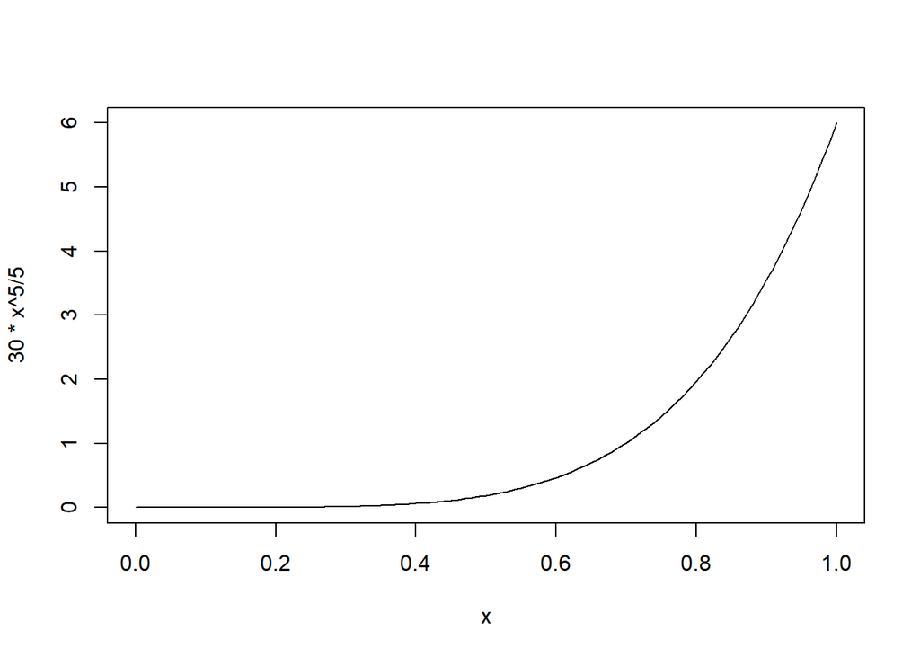

```r
curve(30*x^5/5)
```

# Point Estimation:

# Que: Generate 1000 random sample of size n=7 from a population of size N=25,

# where the items in the population are sequentially numbered from 1 to N,What

# are the method of moments and maximum likehood estimate of N for these sample.

```r
N=25;n=7
a=matrix(sample(1:N,7000,replace=TRUE),nrow=1000);head(a)
```

```
##      [,1] [,2] [,3] [,4] [,5] [,6] [,7]
## [1,]    4    4    8    2   20    9   14
## [2,]   12   21   18   11   20   16   24
## [3,]    8    4    8    7   12    8    8
## [4,]    7   10    8   12   23   17    6
## [5,]   17    8    5   22    6   14    3
## [6,]   21   15    2    6    6   12   17
```

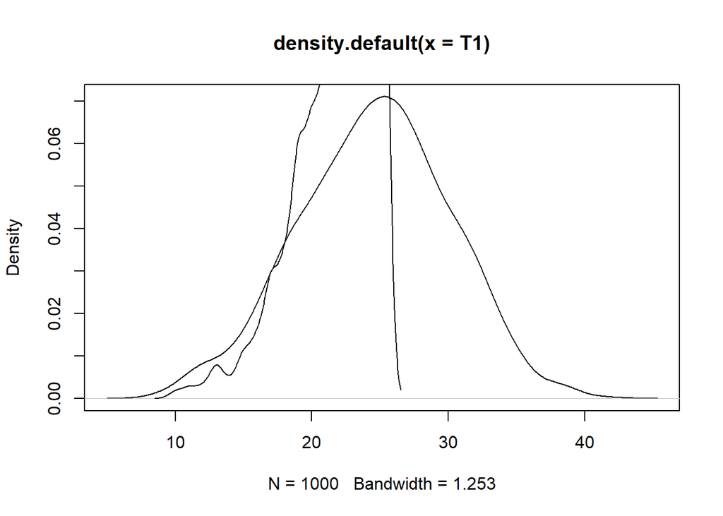

```r
T1=(2*apply(a,1,mean))-1;
T2=apply(a,1,max);
MSE1=mean((T1-N)*(T1-N))
MSE2=mean((T2-N)*(T2-N))
plot(density(T1))
lines(density(T2))
```

# Que: Generate 1000 samples from exponential distribution with mean theta of size 3 # and find the following estimators of theta: 1)theta1_hat= X1 # 2)theta2_hat=(X1+X2)/2 # 3)theta3_hat=Xbar # 4)theta4_hat=min{X1,X2,X3} # A)Find the mean and variance of each estimator.Are any of the estimstor efficiencient? # B)Which estimator is the MLE?Which estimator is an unbiased estimator of theta?

```r
theta=0.5
s=matrix(rexp(3000,1/theta),nrow=1000)
t1=s[,1]
t2=(s[,1]+s[,2])/2
t3=apply(s,1,mean)
t4=apply(s,1,min)
t=cbind(t1,t2,t3,t4)
Mean=apply(t,2,mean)
Var=apply(t,2,var)
MSE=apply((t-theta)^2,2,mean)
rbind("EST_Mean"=Mean,"Var"=Var,"MSE"=MSE)
```

```
##                 t1         t2         t3         t4
## EST_Mean 0.4778747 0.45791069 0.47809234 0.15483204
## Var      0.2212917 0.09676465 0.07688115 0.02391954
## MSE      0.2215599 0.09843939 0.07728421 0.14303654
```

```r
names(which.min(MSE))
```

```
## [1] "t3"
```

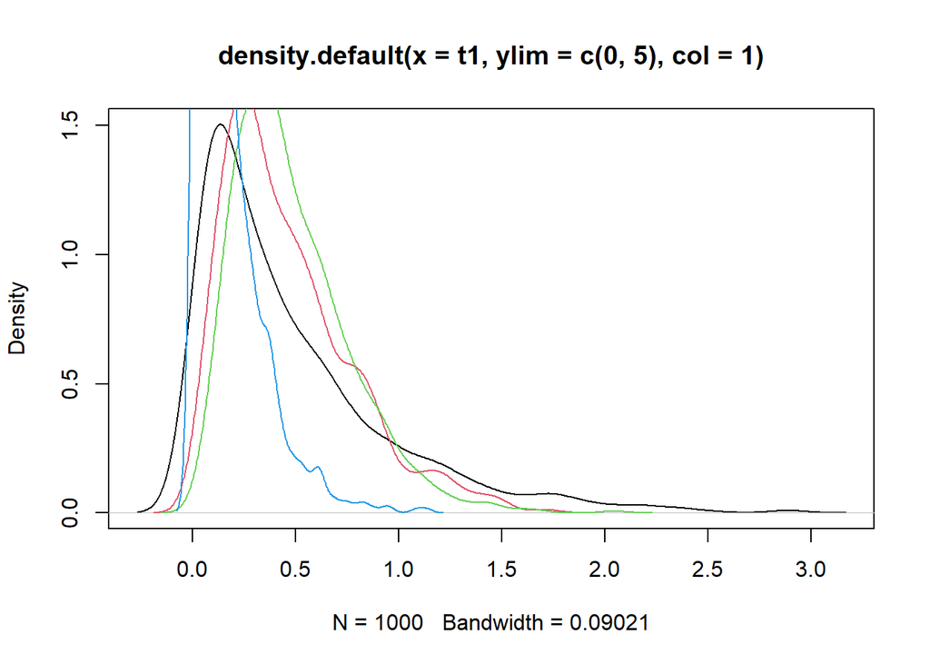

```r
plot(density(t1,ylim=c(0,5),col=1))
lines(density(t2),col=2)
lines(density(t3),col=3)
lines(density(t4),col=4)
```